# További FAE becslések és a Bootstrap módszer

Kovács László

2023. 02. 10.

## 1. A Konfidencia-intervallumok két általános tulajdonsága

Az átlagra vonatkozó konfidencia-intervallumokkal kapcsolatos számolások során megállapítottunk **két olyan általános tulajdonságot a konfidencia-intervallumok hosszára, azaz a teljes becslési hibahatárra** $\triangle$-re vonatkozóvan, **amelyek igazak lesznek az összes többi** - a tárgyban vizsgált - **statisztikai mutató konfidencia-intervallumára** is:

1. A megbízhatóság növelésével a konfidencia-intervallum egyre csak tágul, azaz a becslési hibahatár folyamatosan nő. Tehát, **nagyobb megbízhatóságú becslés csak pontatlanabb konfidencia-intervallum árán érhető el**.
2. Mivel a továbbiakban is konzisztensen viselkedő becslőfüggvényekkel ($\hat{\theta}$-kal) fogunk dolgozni, így kijelenthető, hogy a **mintaelemszám ($n$) növelésével**, a $SH$ értéke csökken. A csökkenő $SH$ miatt pedig **az egész konfidencia-intervallum pontosabb lesz**. **Magyarul** az elemszém növelésével a konfidencia-intervallum hossza, leánykori nevén **becslési hibahatár** ($\triangle$) **csökken**.

A következő két fejezetben figyeljük meg, hogy **minden újabb statisztikai mutató konfidencia-intervalluma a feni két tulajdonságot betartva fog viselkedni**!

## 2. Arányok konfidencia-intervalluma

Vegyük elő újra a ESS2020.xlsx fájlban található adatbázist! Emlékeztetőül álljon itt, hogy ez az adatbázis a 2020-ban végzett európai szociális felmérés (European Social Survey 2020 = ESS2020) 1849 magyar kitöltöjének válaszait tartalmazza 14 kérdésre (plusz van egy *id* oszlop).

Ugyebár az előző tananyag 4. fejezet 2. feladatában azt mondtuk, hogy ha az adatbázis valamelyik oszlopában üres értéket találunk, akkor az azt jelenti, hogy az adott sorban lévő kitöltő nem válaszolt a kérdésre. Az adatbázisban szereplő kitöltők a teljes 18 év feletti magyar népességből vett véletlen mintaként kezelhetők. Most feltesszük, hogy ez a véletlen minta visszatevéses, azaz $FAE$ is. A következő tananyagban látni fogjuk, hogy ez nem is valóságtól elrugaszkodott feltevés.

Először is töltsök be az adatbázist ismét az Excelből egy `pandas` data frame-be és nézzük meg az `info` metódussal milyen oszlopaink (azaz ismérveink) vannak!

```python
# Elemzéshez és ábrázoláshoz szükséges csomagok betöltése
import numpy as np
import pandas as pd
import matplotlib.pyplot as plt
import scipy.stats as stats
from statsmodels.stats.meta_analysis import combine_effects
from statsmodels.graphics.dotplots import dot_plot

# Adatbeolvasás data frame-be
ESS = pd.read_excel("ESS2020.xlsx")
ESS.info()
```

```
## <class 'pandas.core.frame.DataFrame'>
## RangeIndex: 1849 entries, 0 to 1848
## Data columns (total 15 columns):
##  #   Column                          Non-Null Count  Dtype
## ---  ------                          --------------  -----
##  0   id                              1849 non-null   int64
##  1   PoliticalRadioTVPerDay_Minutes  1796 non-null   float64
##  2   NetUsePerDay_Minutes            1099 non-null   float64
##  3   TrustInParlament                1849 non-null   object
##  4   PoliticalPartyPref              1849 non-null   object
##  5   Education_Years                 1830 non-null   float64
##  6   WeeklyWork_Hours                685 non-null    float64
##  7   Region                          1849 non-null   object
##  8   County                          1849 non-null   object
##  9   SecretGroupInfluenceWorldPol    1849 non-null   object
##  10  ScientistsDecievePublic         1849 non-null   object
##  11  COVID19                         1849 non-null   object
##  12  ContactCOVID19                  1849 non-null   object
##  13  GetVaccince                     1849 non-null   object
##  14  SomeContactCOVID19              1849 non-null   object
## dtypes: float64(4), int64(1), object(10)
## memory usage: 216.8+ KB
```

Láthatjuk, hogy megvan mind a 14+1 változónk a megfelelő adattípusokkal. Hurrá! :)

**Feladatunk** ezúttal az lenne, hogy **99%-os megbízhatóságú konfidencia-intervallum**ot építsünk a **Fideszt támogatók arányára!**

Szerencsére ezt aránylag könnyű megtenni, hiszen **egy adott tulajdonsággal bíró egyedek aránya lényegében egy átlag**! Konkrétan **egy olyan változó átlaga, ahol a tulajdonsággal bíró egyedek $1$ értéket, míg a tulajdonsággal NEM rendelkező egyedek $0$ értéket kapnak**.

Ezt könnyű is szemléltetni Python-ban. Vegyük a feladat szempontjából releváns a `PoliticalPartyPref` ismérv **relatív gyakoriságait** a `value_counts` metódus segítségével:

```python
# Teljes mintaelemszám megadása
n = ESS.PoliticalPartyPref.count()

# Relatív Gyakoriságok
ESS.PoliticalPartyPref.value_counts() / n
```

```
## Nem Ismert           0.643050
## Fidesz-KDNP          0.197404
## Egyesült Ellenzék    0.148729
## Egyéb                0.010817
## Name: PoliticalPartyPref, dtype: float64
```

Ez alapján ugye a Fidesz támogatóinak aránya a megfigyelt 1849 elemű mintában $19.7\%$. Ezt az eredményt pedig úgy is megkaphatjuk, hogy csinálunk egy új `Fidesz` nevű oszlopot az `ESS` nevű data frame-be, amiben a Fidesz támogatók $1$ értéket kapnak, a többiek $0$-t, és vesszük az új oszlop átlagát.  
Az új oszlop létrehozásához a `numpy` csomag `where` néven futó függvényét használjuk. Ez lényegében olyan, mint az Excel `HA` függvénye: egy logikai feltétel megadása után értéket adunk az új oszlopban a *feltétel igaz* ágon, majd utána a *feltétel hamis* ágon.

```python
# Létrehozzuk a Fidesz nevű oszlopot!
ESS['Fidesz'] = np.where(ESS.PoliticalPartyPref=='Fidesz-KDNP', 1, 0)

# És vesszük az új oszlop átlagát
np.average(ESS.Fidesz)
```

```
## 0.19740400216333154
```

Ismét megkaptuk a $19.7\%$-os támogatottsági arányt. Ez alapján pedig könnyen elkészíthetjük rá a 99%-os megíbzhatóságú konfidencia-intervallumot a `scipy` csomag `stats.norm.interval` függvényével. Hiszen a nagy mintaelemszám miatt nem szükséges a $k$ szorzót t-eloszlásból számolni, bőven megfelel nekünk a standard normális eloszlás alkalmazása is.

```python
stats.norm.interval(
  alpha=0.99,
  loc=np.mean(ESS.Fidesz),
  scale=stats.sem(ESS.Fidesz, nan_policy = 'omit'))
```

```
## (0.1735537723743666, 0.2212542319522965)
##
```

Tehát, a mintánk alapján a **magyar népesség egészét tekintve az mondható el, hogy 99%-os valószínűséggel legalább $17.4\%$-uk támogatja a Fidesz-KDNP-t, viszont szintén 99%-os valószínűséggel kijelenthető, hogy a támogatottsági arányuk nem magasabb $22.1\%$-nál**.

A teljes népességre nézve vett Fidesz támogatottság vizsgálható a `statsmodels` csomag `combine_effects` függvényével **regionális bontásban** is.

Mielőtt a `combine_effects` függvényt használnánk, csináljuk meg a kiinduló kimutatást az `ESS` data frame `groupby` metódusával:

1. A nominális ismérvünk, azaz most a `Region` egyedi értékei szerint vesszük az átlaggal vizsgált mennyiségi ismérv (most `Fidesz`) részátlagait
2. Utána ezen részátlagok $SH^2$-eit, azaz *becslési varianciáit* is megadjuk.

```python
RegionKimutatas = ESS.groupby("Region").agg(
  Elemszam = ('Fidesz', 'count'),
  Atlag = ("Fidesz", np.mean),
  SH = ("Fidesz", stats.sem)
)
# SH négyzetre emelés
RegionKimutatas['BecslesiVar'] = RegionKimutatas['SH']**2

RegionKimutatas
```

```
##                     Elemszam     Atlag        SH  BecslesiVar
## Region
## Budapest                 298  0.248322  0.025069     0.000628
## Dél-Alföld               167  0.125749  0.025734     0.000662
## Dél-Dunántúl             143  0.153846  0.030278     0.000917
## Közép-Dunántúl           242  0.219008  0.026641     0.000710
## Nyugat-Dunántúl          221  0.167421  0.025171     0.000634
## Pest                     265  0.222642  0.025604     0.000656
## Észak-Alföld             305  0.144262  0.020152     0.000406
## Észak-Magyarország       208  0.264423  0.030653     0.000940
```

Látható, hogy a mintán belül a Fidesz támogatottsága az Dél-Dunántúlon csak 15.4%, míg Nyugat-Dunántúlon 16.7%. Kérdés, hogy ezek a különbségek a mintavételi hiba, azaz a 99%-os megbízhatóságú konfidencia-intervallum figyelembe vételével is megmaradnak-e!

Ami fontos még az előbb elkészített kimutatásból, hogy **minden régióban megvan a nagy elemszám** ($n>30$), így nyugodtan használható a $k$ megbízhatósági szorzót standard normális eloszlásból számító `combine_effects` függvény. A függvény paraméterezési szabályait lásd a 4. heti tananyag 6. fejezetében.

```python
eredmeny = combine_effects(
  effect = RegionKimutatas.Atlag,
  variance = RegionKimutatas.BecslesiVar,
  row_names = RegionKimutatas.index,
  alpha = (1-0.99)
)

# a summary_frame eredményéból az első 8 sor kell nekünk,
# mert 8 régió szerint vizsgáljuk a támogatottsági arányokat!
eredmeny_tabla = eredmeny.summary_frame().iloc[0:8,0:4]
eredmeny_tabla
```

```
##                          eff    sd_eff    ci_low    ci_upp
## Budapest            0.248322  0.025069  0.199187  0.297457
## Dél-Alföld          0.125749  0.025734  0.075310  0.176187
## Dél-Dunántúl        0.153846  0.030278  0.094503  0.213189
## Közép-Dunántúl      0.219008  0.026641  0.166794  0.271223
## Nyugat-Dunántúl     0.167421  0.025171  0.118086  0.216756
## Pest                0.222642  0.025604  0.172458  0.272825
## Észak-Alföld        0.144262  0.020152  0.104766  0.183759
## Észak-Magyarország  0.264423  0.030653  0.204344  0.324503
```

Az eredményül kapott táblából ismételten látható, hogy a **mintán belül a Fidesz támogatottsága az Dél-Alföldön csak 12.6%, míg Dél-Dunántúlon már 15.4%**. Azonban, ha a konfidencia-intervallum segítségével a **teljes népességet vizsgáljuk, akkor ez 99%-os valószínűséggel egy NEM szignifikáns** (jelentős) **eltérés, mivel a két konfidencia-intervallum metszi egymást!** Tehát a teljes népességben elképzelhető legjobb esetben egy 17.6%-os támogatottság is a Dél-Alföldön, míg a legrosszabb esetben belefér a Dél-Dunántúlon 9.5%-os támogatottság is. Tehát, az, hogy a Dél-Dunántúlon magasabb a Fidesz támogatottsági arány a mintában, az lehet csak a mintavételi hiba műve 99%-os megbízhatósággal! Ellenben az **Észak-Magyarországi Fidesz támogatottság 99% valószínűséggel a sokaságban is magasabb, mint a Dél-Alföldi**, hiszen a Dél-Alföldön a támogatottság legjobb esetben is csak 17.6%, míg Észak-Magyarországon legrosszabb esetben is már 20.4%. Tehát a **két konfidencia-intervallum NEM metszi egymást, a mintában mért eltérések 99% valószínűséggel megmaradnak a sokaságban is!**

Az eredményekről ugyan úgy készíthetünk **forest diagram**ot, mint a pártpreferenciák szerint bontott átlagos netezési időkről a 4. heti tananyag 6. fejezetében. Itt ugyebár a `statsmodels` csomag `dot_plot` függvényét vetjük be. Ennek a használatáról is bővebb információk a 4. heti tananyag 6. fejezetében találhatók.

```python
# konfidencia-intervallumok méretének megadása az ábrához
intervallumok = np.abs(eredmeny_tabla[["ci_low", "ci_upp"]] - eredmeny_tabla[["eff"]].values)
intervallumok

# ábra elkészítése
```

```
##                       ci_low    ci_upp
## Budapest            0.049135  0.049135
## Dél-Alföld          0.050439  0.050439
## Dél-Dunántúl        0.059343  0.059343
## Közép-Dunántúl      0.052215  0.052215
## Nyugat-Dunántúl     0.049335  0.049335
## Pest                0.050183  0.050183
## Észak-Alföld        0.039496  0.039496
## Észak-Magyarország  0.060080  0.060080
```

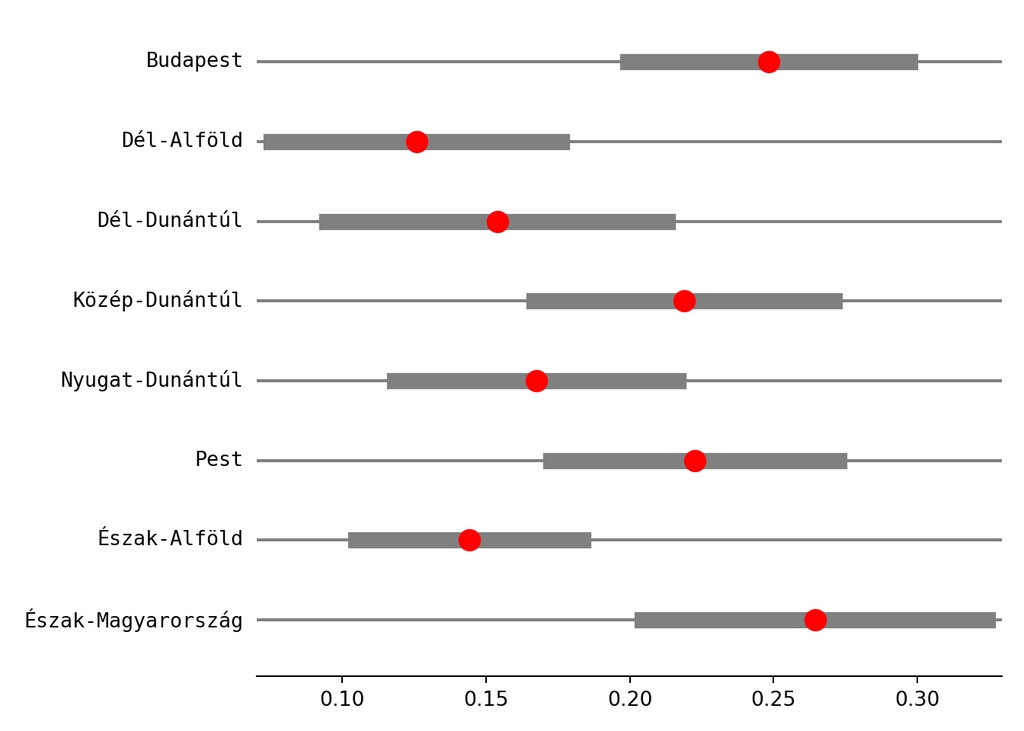

```python
dot_plot(
  points=eredmeny_tabla["eff"],
  intervals = intervallumok,
  lines=eredmeny_tabla.index)

# ábra megjelenítése
plt.tight_layout() # ne csússzanak ki a tengelyfeliratok
plt.show()
```

### 2.1. Mintaelemszám meghatározása aránybecsléshez

Érdemes az arány konfidencia-intervallumának számítása során felhasználni azt az információt, hogy egy csak 0-ból és 1-ből álló változó korrigált mintaszórása $s=\sqrt{p(1-p)}$ módon számítható, ahol $p$ az $1$ értékek aránya a mintában!  
Nézzük is meg, hogy igaz-e ez! Ugyebár a Fidesz támogatottsági aránya a teljes 1849 elemű mintában $p=19.7\%$. Ez alapján a szórása a `Fidesz` nevű 0-1-ből álló változónak $s=\sqrt{p(1-p)}=\sqrt{0.197 \times (1-0.197)}=0.3977323$.

Nézzük meg az eredményt a `numpy` csomag `std` függvényével is:

```python
np.std(ESS.Fidesz)
```

```
## 0.3980397745115819
```

A kétféleképp számolt érték némi kerekítési hibát leszámítva egyezik! :) De hát ez nem meglepő, hogy így alakult, hiszen a 3. heti tananyag 5. fejezetében éppen azt mondtuk, hogy a mintaarányok (a $p$-k) standard mintavételi hibája a $SH(p) \approx \sqrt{\frac{p(1-p)}{n}}$ képlettel megadható. :)

Ez azt jelenti, hogy **az arány konfidencia-intervallumának hossza** a $\triangle = SH \times k$ képlet alapján $\sqrt{\frac{p(1-p)}{n}} \times k$ módon számítható, hiszen az átlag standard hibája $\frac{s}{\sqrt{n}}$ volt, és most felhasználtuk, hogy csak 0-1-et tartalmazó változókra $s=\sqrt{p(1-p)}$. A $k$ megbízhatósági szorzó pedig ugyan úgy $N(0,1)$ eloszlással számolható *nagy méretű minták esetén*, mint az átlag konfidencia-intervallumánál. Hiszen magas $n$ esetén a $t(n-1)$ eloszlás sűrűségfüggvénye már lényegében egybeesik az $N(0,1)$ eloszlás sűrűségfüggvényével, ahogy a 4. heti tananyag 4. fejezetének 2. feladatában is láttuk.

**Ennyi információ alapján pedig képesek vagyunk arra, hogy még mintavétel ELŐTT meghatározzuk, hogy az arány egy adott pontosságú és megbízhatóságú becsléséhez mekkora elemszámú mintára van szükségünk**.

Hiszen $99\%$-os megbízhatósági szint mellett a szükséges megbízhatósági $k$ szorzó a standard normális, azaz $N(0,1)$ eloszlás inverz értéke alapján megadható $z_{1-\frac{\alpha}{2}}$ módon:

```python
alfa=1-0.99
stats.norm.ppf(1-alfa/2)
```

```
## 2.5758293035489004
```

Vegyük az értéket kerekítve $k=2.6$-nak!

Ugyebár azt tudjuk, hogy a jelenlegi 1849 elemű mintánk esetén Fidesz támogatottsági aránya $p=19.7\%$, **amitől a támogatottsági arány valós sokasági értéke** 99%-os valószínűséggel $\pm$ **2.4 százalékpontos hibahatárral térhet el**:
$$\pm \triangle = SH \times k = \sqrt{\frac{p(1-p)}{n}} \times k = \sqrt{\frac{0.197 \times (1-0.197)}{1849}} \times 2.6=0.0240$$

De mi a helyzet, ha a **hibahatár értékét 1 százalékpontra akarom csökkenteni és meg akarom őrizni a 99%-os megízhatósági szintet**? Ekkor **nagyobb mintát kell venni, kérdés, hogy mennyivel nagyobbat**. Ezek alapján a kívánt $\triangle$ érték $0.01$ és a $k=2.6$ értékből sem akarok engedi. Azaz:
$$0.01 = \sqrt{\frac{p(1-p)}{n}} \times 2.6$$

Ebből $n$-t kifejezve:
$$n=\frac{2.6^2 \times p(1-p)}{0.01^2}$$

Ezen a ponton nagy a csábítás, hogy a képletből úgy számoljuk ki $n-t$, hogy $p=19.7\%$-kal dolgozzunk. De ezt **ne tegyük**! Mivel nem tudjuk, hogy a megnövelt elemszámú mintában mennyi is lesz $p$. Plusz, ha a **szükséges mintaelemszámot AZELŐTT akarjuk meghatározni, hogy a kérdéses $p$ arány becslésére már vettünk mintát, akkor aztán tényleg lövésünk nincs a $p$ értékéről**!

Szerencsére, **rájöhetünk, hogy a $p(1-p)$ kifejezésnek könnyen meg tudjuk adni a maximumát**, hiszen az $f(p)=p(1-p)=p-p^2$ függvény egy fordította parabola, melynek maximuma $p=0.5$-nél kerül felvételre és értéke $max(p(1-p))=0.25$:

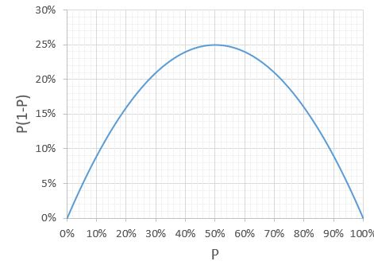

Szóval az $N=\frac{2.6^2 \times p(1-p)}{0.01^2}$ formulába **mindig beírhatjuk a $0.25$-öt, hiszen ez a legrosszabb szituációnk, ekkor lesz aránybecslés esetén maximális a standard hibánk**. Ha elégség nagy mintát veszünk, hogy a maximális $SH$ mellett is $\triangle = 0.01$-et érjünk el, akkor minden egyéb esetben is jók vagyunk.

Tehát, **az 1 százalékpontos hibahatár eléréséhez szükséges elemszám 99%-os megbízhatóság mellett** $N=\frac{2.6^2 \times 0.25}{0.01^2}=16900$ **fő**.  
Ennek fényében különsöen érdekes meglesni [ezen a linken](https://ig.ft.com/sites/brexit-polling/) hogy hány fős mintából dolgoztak a 2016-os Brexit népszavazás eredményének előrejelzése során a közvéleménykutatók, ahol lehetett tudni, hogy nagyon kiélezett a verseny a maradás és elszakadás pártok között, így a két párt támogatottsági arányának becslése során **nagyon szükség lett volna erre az 1 százalékpontos hibahatárra és a 99%-os megbízhatósági szintre, ami a 16900 elemű minták biztosítanak arányok becslése során**.

További érdekes példaként vegyük a Momentum Mozgalom 2021. október 11-én megosztott plakátját:

[figure not shown]

Ha megnézzük a kép jobb alsó sarkát láthatjuk, hogy az adatok forrása a Medián közvélemény kutató intézet. A dátum alapján rájöhetünk, hogy [erről a Medián közvéleménykutatásról szól a plakát](https://hvg.hu/itthon/20211011_Median_MarkiZay_elonyhoz_juttathatja_az_ellenzeket). A linkelt HVG cikkből megtudhatjuk, hogy a Medián közvéleménykutatása egy $n=1000$ elemű véletlen mintát takar. Ebben az esetben számoljuk ki a különböző pártlisták támogatottsági arányaihoz a maximális $\triangle$ hibahatárt, azaz vegyük $p(1-p)$-t $0.25$-nek:
$$\pm \triangle = SH \times k = \sqrt{\frac{p(1-p)}{n}} \times k = \sqrt{\frac{0.25}{1000}} \times 2.6=0.0411$$

Tehát a hibahatár durván **4 százalékpont**. Ha ezt az értéket Dobrev Klára esetén levonjuk a Fidesz támmogatottsági arányából és hozzáadjuk az Ellenzék témogatottsági arányához, majd ha MZP esetén az Ellenzéki arányból levonjuk és a Fideszhez hozzáadjuk, akkor láthatjuk, hogy **a plakáton kimutatott Fidesz és Ellenzéki pártlisták támogatottsági arányai közötti különbség MZP és Dobrev esetén is bőven a mintavételi hibahatáron belül van**!  
Tehát, egyik esetben sem mondható el a konfidencia-intervallum alapján, hogy a teljes népességben reális lenne a plakát állítása, miszerint csak MZP-vel verhető a Fidesz. Az **plakát üzenete csak a megfigyelt 1000 elemű mintán belül vehető igaznak**! Amit meg is erősít a 2022-es országgyűlési választások eredménye…

### 2.2. Szükséges minimális elemszám aránybecsléshez

Az **arány intervallumbecslés** esetén **van** a 2.1. fejezetben taglaltak mellett egy **minimális elemszám követelménye is, aminél kisebb mintákban az intervallumbecslés egyáltalán NEM elvégezhető!!**

Ez a követelemény abból jön, hogy az aránybecslést gyakorlatilag egy átlagbecslésre vezetjük vissza.  
Hiszen átlagbecslés esetén **kis elemszámú mintáknál feltételezzük az alapsokaság** (tehát, amiből a mintát vettük) **normális eloszlását, még akkor is, ha a megbízhatósági szorzót t-eloszlásból számítjuk!** Egy **csak $0$-ból és $1$-ből álló adatsor pedig bajosan fog normális eloszlást követni!** :)

Azt, hogy **mi számít aránybecslés esetén nagy mintának, a következő szabály adja meg**:

- Legyen az arány szempontjából *kedvező* esetek száma több, mint 10 a mintában, azaz: $n \times p >10$
- Legyen az arány szempontjából *kedvezőtlen* esetek száma is több, mint 10 a mintában, azaz: $n \times (1-p) >10$

Ez a Fidesz támogatók arányának korűábbi példájára nézve úgy néz ki, hogy a teljes mintánk elemszáma $n=1849$ fő:

```python
len(ESS) # tábla sorainak száma
```

```
## 1849
```

Míg az arány szempontjából *kedvező* esetek, azaz a Fidesz-KDNP támogatók száma $365$ fő:

```python
ESS.loc[ESS['PoliticalPartyPref'] == 'Fidesz-KDNP', 'PoliticalPartyPref'].count()
```

```
## 365
```

Tehát a **két feltétel itt a következőképpen teljesül**:

- A *kedvező* esetek száma $365 > 10 \rightarrow$ **feltétel teljesül**
- A *kedvezőtlen* esetek száma $(1849-365) = 1484 > 10 \rightarrow$ **feltétel teljesül**

Tehát, **mindkét feltétel teljesül**, a Fidesz támogatók arányának **intervallumbecslése elvégezhető** volt, mivel **megvan a minimális mintaelemszám**. Yeah! :)

### 2.3. Aránybecslés a `statsmodels` csomaggal

Érdemes megemlékezni arról is, hogy Pythonban nem csak a `scipy` csomag segítségével lehet arányra vonatkozó intervallumbecslést készíteni hanem a `statsmodels` csomagban is van erre beépített megoldás.

A `scipy` csomagban a `stats.norm.interval` függvény alkalmazásához ugyebár készíteni kellett egy külön új oszlopota data frame-ben az aránybecsléshez, ahol $1$-gyel jelöltük az arányban vizsgált tulajdonsággal rendelkező mintaelemeket, $0$-val a tulajdonsággal nem rendelkezőket. És a trükk az volt, hogy az arányra úgy tekintünk, mint az új $0$-kat és $1$-eket tartalmazó oszlop átlagára.

Ha ezt az **új oszlop létrehozást meg akarjuk úszni**, akkor jöhet jól a `statsmodels` csomag `stats.proportion_confint` függvénye. Ebben a függvényben csak a következő paramétereket kell megadni:

- `count`: Kedvező eseteket száma a mintában. Tehát azon értékek száma, amiket a `scipy`-os megoldásban $1$-gyel kódolnánk az új oszlopban.
- `nobs`: Minta teljes elemszáma, tehát az $n$.
- `alpha`: A megengedett becslési hibavalószínűség, tehát az $\alpha$. Szóval, itt tényleg az $1-$ *megbízhatósági szint* kell.
- `method`: Itt kell megadni, hogy a $k$ megbízhatósági szorzót milyen eloszlásból számítjuk. Mi nagy mintaméretet feltételezve mindig maradunk a standard normális eloszlásnál, ami itt a `'normal'` beállításnak fog megfelelni.

A fenti paraméterek megértése után nézzük meg hogyan tudjuk az `ESS` adatbázison keresztül megbecsülni a magyar népességben a Fidesz támogatók arányát a teljes népességben ezzel a `stats.proportion_confint` függvénnyel! :)

Először is kell egy kedvező esetek száma, ez a Fidesz-KDNP-t támogatók gyakorisága a data frame-ben a `PoliticalPartyPref` oszlop alapján. Utána pedig lövünk egy $n$-t, ami természetesen a data frame sorinak a száma:

```python
kedvezo_esetek = ESS.loc[ESS['PoliticalPartyPref'] == 'Fidesz-KDNP', 'PoliticalPartyPref'].count()
osszes_eset = len(ESS) # tábla sorainak száma

kedvezo_esetek
```

```
## 365
```

```python
osszes_eset
```

```
## 1849
```

Szuper, megvagyunk! Van összesen $n=1849$ megfigyelés és ebből $365$ Fidesz támogatónk. Ez utóbbi akkor a kedvező esetek száma. :)

Paraméterezzük akkor ezzel fel a `stats.proportion_confint` függvényt, a korábbiakhoz haosnlóan $99\%$-os megbízhatósági szintet használva:

```python
# Betöltjük a csomagot
import statsmodels.api as sm

# Használjuk a függvényt
sm.stats.proportion_confint(count=kedvezo_esetek, nobs=osszes_eset, alpha=(1-0.99), method='normal')
```

```
## (0.17356022274089133, 0.22124778158577174)
```

Nagyon szépen láthatjuk a korább eredményünk: a Fidesz támogatók aránya a teljes magyar népességben $17.4\%$ és $22.1\%$ között található $99\%$ valószínűséggel.

Sőt, ha figyelembe vesszük, hogy a teljes magyar népesség 2020. január 1-jén 9 772 756 fő volt, akkor megkaphatjuk, hogy **konkrétan hány főnyi Fidesz támogató lehet a magyar népességben** $99\%$-os megbízhatósággal. Egyszerűen csak **az arány konfidencia-intervallum két határát kell felszorozni az $N=9772756$-os sokasági elemszámmal**.

```python
[round(0.174 * 9772756, 0), round(0.221 * 9772756, 0)]
```

```
## [1700460.0, 2159779.0]
```

## 3. A Bootstrap becslések általános elve

Eddig a konfidencia-intervallumokkal kapcsolatban elég könnyű dolgunk volt *úgymond*, mert az **átlag és arány esetében** is a konfidencia inztervallum hosszát ($\triangle$-t) ki tudtuk számolni standard hiba ($SH$) szorozva megbízhatósági szorzó ($k$) elven:
$$\triangle=SH \times k$$

Azért tudott ez a formuula működni, mert a **standard hibára tudtunk adni egy egyszerű képletet** ($\frac{s}{\sqrt{n}}$ vagy $\sqrt{\frac{p(1-p)}{n}}$) és **a $k$-t ki tudtuk számolni valami konkrét eloszlásból** (standard normális vagy t-eloszlás).

NODE, **mi a helyzet ha ezek az eszközök NEM állnak rendelkezésre?** Tehát, mi van akkor, ha

1. A standard hibáját egy statisztikai mutatónak (paraméternek, azaz $\theta$-nak) nem lehet egysezrű képlettel kiszámolni.
2. A $k$ számolásához nincs konkrét eloszlás, vagy ami van, az csak lehetetlen feltételekkel alkalmazható (pl. a vizsgált alapsokaság, amiből a mintát vettük az legyen normális eloszlású, mintamérettől függetlenül)

Ezekben az esetekben **segít rajtunk a Bootstrap becslés**! Nézzük meg ennek a módszernek **mi az általános alapelve z átlag standard hibáján keresztül**.

Ugyebár az átlag standard hibája úgy jön ki egy mintavételből, hogy fogjuk a minta korrigált szórását, $s$-t, és ezt elosztjuk a mintaelemszám ($n$) gyökével:
$$SH(\bar{y})=\frac{s}{\sqrt{n}}$$

Számoljuk ki az `ESS` adatbázisból a napi netezési idő (`NetUsePerDay_Minutes` oszlop) átlagának standard hibáját! Csak emlékezzünk, hogy a `NetUsePerDay_Minutes` oszlopban volt pár hiányzó érték, ezeket ne vegyük figyelembe az $n$ meghatározásakor!

```python
n = ESS.NetUsePerDay_Minutes.count() # így nem számoljuk be az üres értékeket

korr_szoras = np.std(ESS.NetUsePerDay_Minutes, ddof = 1)

SH_Keplet = korr_szoras / np.sqrt(n)
SH_Keplet
```

```
## 4.381340690645104
```

Szuper, a mintaátlag várható eltérése a valós, sokasági átlagos netezési időtől várhatóan $\pm4.38$ perc!

**Hogyan jön ki ez az eredmény Bootstrap módon?**

A **Bootstrap becslés alapötlete a standard hiba alap definíciójából jön**, amit a 3. heti tananyag 5. fejezetében néztünk. **Vegyünk ki a sokaságból nagyon-nagyon sok** (pl. 1000 vagy 10000 db) **visszatevéses** (azaz FAE) **mintát, minden mintából számoljuk mi a mintaátlagot és a mintaátlagok szórása a standard hiba** az átlagbecslés *torzítatlanság*a miatt.  
Ugyebár ezzel a megközelítéssel az a **baj, hogy a gyakorlatban csak egyetlen egy darab mintánk van, és nem ismerjük a sokaságot, így nem tudunk belőle nagyon-nagyon sok FAE mintát kivenni**.  
Nos, a **Bootstrap módszer azt mondja, hogy ezt az alap szórás-elvű $SH$ számolást tudjuk SZIMULÁLNI akár egyetlen egy darab mintavételből is!**

Ha **van egy $n$ elemű mintánk, akkor abból vegyünk ki nagyon-nagyon sok (pl. 1000 db) szintén $n$ elemű FAE almintát!!** A **FAE, azaz visszatevéses elv miatt, az $n$ elemű alminták összetétele véletlenszerűen meg fog változni, és ezek a véletlen változások épp a mintavételi hiba tendenciáit követik le!!**  
Ezek után más dolgounk nincs, mint **kiszámolni minden almintából a mintaátlagot, és venni ezek sima, korrigálatlan szórását, és ez lesz a $SH$!!**

Lássuk akkor ezt a dolgot a gyakorlatban! **Számoljuk ki az átlag standard hibáját Bootstrap elven!**

Először is **vegyünk a `NetUsePerDay_Minutes` oszlopból mondjuk $1000$ db FAE mintát, és tároljuk le ezeket az almintákat egy olyan data frame-ben, aminek $1000$ sorában lesznek a különböző mintavételek, míg $n$ db oszlopában az $n$ db mintaelem minden egyes mintavételezési körben**.  
Itt gyakorlatilag ugyanazokat a megoldásokat követjük Pythonban, mint a 2. heti tananyag 3.1. fejezetében.

**Készítsük el először az almintákat tároló üres data frame-t!** Mivel $1099$ db nem hiányzó értéke van a `NetUsePerDay_Minutes` oszlopnak, így $n=1099$ oszlopa lesz az új data frame-nek!

```python
n = ESS.NetUsePerDay_Minutes.count() # így nem számoljuk be az üres értékeket

oszlopnevek = (np.array(range(n))+1)
oszlopnevek = oszlopnevek.astype(str)
oszlopnevek = np.core.defchararray.add("Elem", oszlopnevek)
oszlopnevek
```

```
## array(['Elem1', 'Elem2', 'Elem3', ..., 'Elem1097', 'Elem1098', 'Elem1099'],
##       dtype='<U15')
```

```python
MintaDF = pd.DataFrame(columns = oszlopnevek)
MintaDF
```

```
## Empty DataFrame
## Columns: [Elem1, Elem2, Elem3, Elem4, Elem5, Elem6, Elem7, Elem8, Elem9, Elem10, Elem11, Elem12, Elem13, Elem14, Elem15, Elem16, Elem17, Elem18, Elem19, Elem20, Elem21, Elem22, Elem23, Elem24, Elem25, Elem26, Elem27, Elem28, Elem29, Elem30, Elem31, Elem32, Elem33, Elem34, Elem35, Elem36, Elem37, …
## Index: []
##
## [0 rows x 1099 columns]
```

Majd elkészítünk egy olyan verziót az `ESS` data frame-ből, amiben **nincsenek benne a `NetUsePerDay_Minutes` oszlop hiányzó értékei**. Így egy $n=1099$ soros data frame-ünk lesz.

```python
ESS_Szurt = ESS[ESS['NetUsePerDay_Minutes'].notna()]
ESS_Szurt.info()
```

```
## <class 'pandas.core.frame.DataFrame'>
## Int64Index: 1099 entries, 0 to 1847
## Data columns (total 16 columns):
##  #   Column                          Non-Null Count  Dtype
## ---  ------                          --------------  -----
##  0   id                              1099 non-null   int64
##  1   PoliticalRadioTVPerDay_Minutes  1082 non-null   float64
##  2   NetUsePerDay_Minutes            1099 non-null   float64
##  3   TrustInParlament                1099 non-null   object
##  4   PoliticalPartyPref              1099 non-null   object
##  5   Education_Years                 1090 non-null   float64
##  6   WeeklyWork_Hours                541 non-null    float64
##  7   Region                          1099 non-null   object
##  8   County                          1099 non-null   object
##  9   SecretGroupInfluenceWorldPol    1099 non-null   object
##  10  ScientistsDecievePublic         1099 non-null   object
##  11  COVID19                         1099 non-null   object
##  12  ContactCOVID19                  1099 non-null   object
##  13  GetVaccince                     1099 non-null   object
##  14  SomeContactCOVID19              1099 non-null   object
##  15  Fidesz                          1099 non-null   int32
## dtypes: float64(4), int32(1), int64(1), object(10)
## memory usage: 141.7+ KB
```

Szuper, ezzel megvagyunk!

Akkor most **jöhet az $1000$ db $n=1099$ elemű alminta generálása `for` ciklusból** és a tárolás az újonnan létrehozott data frame-ben.

Most is **megnövekedett futásidőre kell** itt **készülni**! :)

```python
for index in range(1000):
  AktualisMinta = ESS_Szurt['NetUsePerDay_Minutes'].sample(n = len(ESS_Szurt), replace = True)
  AktualisMinta.index = oszlopnevek
  MintaDF = MintaDF.append(AktualisMinta, ignore_index = True)

MintaDF
```

[output not shown]

Akkor meg is van az $1000$ db almintánk! :) Számoljuk ki **mindegyik almintában a mintaátlagot**!  
**Figyeljünk** itt is arra, hogy mivel a data frame oszlopai folyamatosan bővülnek amjd, így manuálisan le kell szorítani a `numpy` statisztikai függvények alkalmazását mindig az első $n=1099$ db oszlopra az `iloc` metódussal!

```python
MintaDF['Atlagok'] = np.mean(MintaDF.iloc[:,0:n], axis=1)

MintaDF
```

[output not shown]

A **standard hibánk pedig akkor ezeknek az alminta-átlagoknak lesz a sima korrigálatlan szórása**!

```python
SH_Bootstrap = np.std(MintaDF.Atlagok)

SH_Bootstrap
```

```
## 4.511376672501351
```

E voilá! Némi kerekítési hiba mellett ez kb. ugyan annyi, mint a $\frac{s}{\sqrt{n}}$ képlettel kapott verzió! :) Illetve, értelemszerűen **itt mindenki más értéket kaphatott, mert nem fixáltuk a véletlenszám generátor magját a mintavételek során**.

```python
[SH_Keplet, SH_Bootstrap]
```

```
## [4.381340690645104, 4.511376672501351]
```

Nyilván, ha **több almintát veszünk, akkor pontosabb lesz a közelítés**. Ezt úgy mondjuk szépen **szakszóval, hogy növeljük a Bootstrap becslés replikációinak számát**. :) Tehát a **replikációk száma az alminták számát jelenti**.

NODE, **mire volt jó, hogy ezt a fránya $SH$-t ilyen körülményesen számoltuk ki a képlet helyett?** Nos, **átlag esetében a világon SEMMIRE!**  
Viszont, ezzel a **Bootstrap elvvel ki tudjuk számolni pl. a napi netezési időnk mediánjának standard hibáját, amire amúgy NINCS olyan egyszerű képlet, mint az átlag standard hibájára!**  
Ugyebár ezt megtehetjük, mert megnéztük a 3. heti tananyag 4. fejezetében, hogya medián is egy *torzítatlanul* becsülhető statisutikai paraméter, mint az átlag.

```python
MintaMedian = np.median(ESS_Szurt.NetUsePerDay_Minutes)
MintaMedian
```

```
## 120.0
```

```python
MintaDF['Medianok'] = np.median(MintaDF.iloc[:,0:n], axis=1)
SH_Median = np.std(MintaDF.Medianok)

SH_Median
```

```
## 11.718634732766441
```

Tehát tudjuk, hogy a megfigyelt $n=1099$ elemű mintában a medián napi netezési idő $120$ perc, és a **standard hibából tudjuk, hogy ez az érték a teljes magyar népesség** (sokaság) **valós medián napi netezési idejétől várhatóan $\pm11.72$ perccel különbözik**.

Innen pedig már csak egy lépés, hogy legyen valami $1-\alpha$ megbízhatósági szintű **konfidencia-intervallumunk a mediánra** ezzel a Bootstrap módszerrel!